# 分析灵敏度

hiox-tech

2026-08-06

# 1 分析目的

分析灵敏度（analytical sensitivity）描述测量系统在低浓度端区分”信号与噪声”的能力，由三个递进的 限值构成：

- **LoB（Limit of Blank，空白限）**：空白样本可能出现的最高测值（95% 分位数）。
- **LoD（Limit of Detection，检出限）**：能以 95% 置信水平区分于空白的**最低浓度**。
- **LoQ（Limit of Quantitation，定量限）**：测量结果达到预设精密度目标（如 CV = 20%）的**最低浓度**。

本文演示如何使用 `ivdtools` 包的 `lob_lod_loq()` 依据 **CLSI EP17-A2** 计算分析灵敏度：

- **LoB** 按 5.3.3.1 参数法：`LoB = M_B + cp·SD_B`，将全部空白结果合并为池，`cp = 1.645/√(1 − 1/(4(B−K)))` 为小样本修正的 95% 单侧分位数（B 为空白结果总数、K 为空白样本数）。
- **LoD** 按 5.4.3：先对非空白低浓度样本拟合 Sadler 精度轮廓模型（方差随浓度），再自 LoB 起做 **固定点迭代** `X = LoB + cp·SD_WL(X)`，`cp = 1.645/√(1 − 1/(4(N_TOT−K)))`。
- **LoQ** 按附录 D1 Example 1（功能灵敏度）：求精度轮廓与目标 CV 水平线的交点 `√Var(X)/X = target_cv`。该 LoQ **仅反映精密度、不含偏差**。

示例数据为确定性的教学数据，仅用于演示流程；正式研究必须依据方案或标准预先规定的实验设计、 目标浓度与接受标准。

```r
library(ivdtools)
library(readr)
```

# 2 函数概述

| 函数 | 主要用途 | 关键输入或输出 |
| --- | --- | --- |
| `lob_lod_loq()` | 一次计算 LoB / LoD / LoQ | 汇总数据、空白样本名、目标 CV |
| `replicate_to_mean()` | 汇总重复测量 | 均值、SD、重复数 n |
| `fit_equation()` | 拟合 Sadler 精度轮廓（内部调用） | `eq="sadler"`、`df_col` |
| `print()` / `plot()` | 结果展示 | 表格式汇总、SD/CV 双面板 |

`lob_lod_loq()` 的输入是**已汇总**的 data.frame：每行一个样本，含样本名称列、均值列（即浓度）、 SD 列与重复数 n 列，列名可自由指定。它内部自动完成 Sadler 最优模型拟合，无需用户手动拟合。

# 3 示例：LoB / LoD / LoQ 分析

## 3.1 读取和核验数据

数据包含 2 个空白样本（blank_A、blank_B）与 6 个低浓度样本（L1–L6），各样本重复测量 （空白各 40 次、低浓度各 30 次），共 260 行。SD 随浓度升高而增大，符合低浓度端”方差随均值增大”的常见情形：

```r
sens <- read_csv("./data/sensitivity.csv", show_col_types = FALSE)
sens <- as.data.frame(sens)
str(sens)
```

```
#> 'data.frame':    260 obs. of  2 variables:
#>  $ sample: chr  "blank_A" "blank_A" "blank_A" "blank_A" ...
#>  $ value : num  0.024 -0.006 0.055 -0.072 0.057 -0.023 -0.05 0.003 0.051 0.029 ...
```

```r
dim(sens)
```

```
#> [1] 260   2
```

```r
table(sens$sample)
```

```
#>
#> blank_A blank_B      L1      L2      L3      L4      L5      L6
#>      40      40      30      30      30      30      30      30
```

## 3.2 逐样本汇总

用 `replicate_to_mean()` 按样本名称分组计算均值、SD 与重复数（分组变量为字符时保留原值， 两个空白各占一行）：

```r
rep <- replicate_to_mean(data.frame(x = sens$sample, y = sens$value),
                         x = "x", y = "y")
rep$sample <- rep$x
rep$mean   <- rep$y_mean
rep$sd     <- rep$y_sd
rep$n      <- rep$y_n
rep[c("sample", "mean", "sd", "n")]
```

| sample | mean | sd | n |
| --- | --- | --- | --- |
| blank_A | 0.0080750 | 0.04561623 | 40 |
| blank_B | -0.0036500 | 0.05287360 | 40 |
| L1 | 0.5327667 | 0.11511694 | 30 |
| L2 | 0.9601000 | 0.14135803 | 30 |
| L3 | 1.9882667 | 0.21709110 | 30 |
| L4 | 5.0710667 | 0.56385703 | 30 |
| L5 | 10.1809667 | 0.96523481 | 30 |
| L6 | 19.8890000 | 2.08779088 | 30 |

## 3.3 计算 LoB / LoD / LoQ

`blank` 参数指定空白样本名称（可多个），`target_cv` 指定 LoQ 的精密度目标：

```r
summ <- rep[c("sample", "mean", "sd", "n")]
res <- lob_lod_loq(summ, sample_col = "sample", mean_col = "mean",
                   sd_col = "sd", n_col = "n",
                   blank = c("blank_A", "blank_B"), target_cv = 0.20)
res
```

```
#> Limit of Blank / Detection / Quantitation (EP17-A2)
#> Precision profile: Sadler; best model = Model_3
#>   Equation            : sigma^2 = b1 + b2 * mu^2
#>   Parameters          : b1 = 0.010196, b2 = 0.010388
#>   Fit                 : AIC = -479.4; RSS = 0.08315; GoF p = 0.9437
#>   LoB  (parametric, B = 80, K = 2) : 0.08357
#>   LoD  (fixed-point)                : 0.2552
#>   LoQ  (CV = 20%)                    : 0.5868
#> Note: LoQ is based on precision ONLY; bias is not included.
```

结果解读：

- **LoB = 0.0836**：空白测值的 95% 分位数（参数法），合并 B = 80 个空白结果、K = 2 个空白样本。
- **LoD = 0.26**：精度轮廓上 `X = LoB + cp·SD(X)` 的固定点，即高于此浓度的测值可判为”非空白”。
- **LoQ = 0.59**（CV = 20%）：达到 20% 精密度目标所需的最低浓度，**仅基于精密度**。

## 3.4 返回对象结构

`lob_lod_loq()` 返回 `sensitivity` 对象，各限值与参数以命名分量保存：

```r
str(res, max.level = 1)
```

```
#> List of 13
#>  $ call     : language lob_lod_loq(data = summ, sample_col = "sample", mean_col = "mean", sd_col = "sd",      n_col = "n", blank = c("bl| __truncated__
#>  $ lob      : num 0.0836
#>  $ lod      : num 0.255
#>  $ loq      : num 0.587
#>  $ n_blank  : int 80
#>  $ B        : int 80
#>  $ K        : int 2
#>  $ target_cv: num 0.2
#>  $ cp_lob   : num 1.65
#>  $ cp_lod   : num 1.65
#>  $ fit      :List of 12
#>   ..- attr(*, "class")= chr "fit_equation"
#>  $ model    : chr "Model_3"
#>  $ notes    : chr(0)
#>  - attr(*, "class")= chr "sensitivity"
```

```r
res$lob
```

```
#> [1] 0.0835705
```

```r
res$lod
```

```
#> [1] 0.2552205
```

```r
res$loq
```

```
#> [1] 0.5867594
```

```r
res$B
```

```
#> [1] 80
```

```r
res$K
```

```
#> [1] 2
```

```r
res$cp_lob
```

```
#> [1] 1.647643
```

```r
res$cp_lod
```

```
#> [1] 1.646183
```

```r
res$model
```

```
#> [1] "Model_3"
```

`cp_lob`、`cp_lod` 即 EP17 的两个小样本修正系数；`model` 为 AIC 选出的最优 Sadler 模型 （本例为模型 3，混合方差型）。

## 3.5 图形

`plot()` 画出 SD 与 CV 两个精度轮廓面板，叠加 LoB / LoD / LoQ 参考线，直观展示各限值的 几何含义：

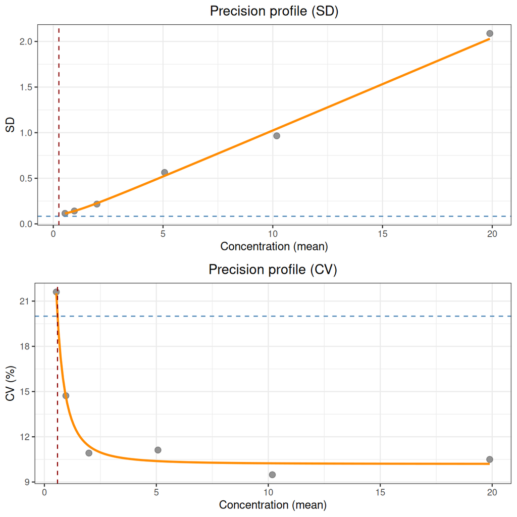

```r
plot(res)
```

# 4 其他输入情形

## 4.1 情形一：仅空白（只算 LoB）

若无低浓度水平，则只计算 LoB，LoD / LoQ 为 `NA`：

```r
res_b <- lob_lod_loq(summ[summ$sample %in% c("blank_A", "blank_B"), ],
                     sample_col = "sample", mean_col = "mean",
                     sd_col = "sd", n_col = "n",
                     blank = c("blank_A", "blank_B"))
res_b
```

```
#> Limit of Blank / Detection / Quantitation (EP17-A2)
#>   LoB  (parametric, B = 80, K = 2) : 0.08357
#>   LoD  (fixed-point)                : --
#>   LoQ  (CV = 20%)                    : --
#> Note: LoQ is based on precision ONLY; bias is not included.
```

## 4.2 情形二：无空白（只算 LoQ）

若无空白样本（`blank = NULL`），则只计算 LoQ，LoB / LoD 为 `NA`：

```r
res_q <- lob_lod_loq(summ[!summ$sample %in% c("blank_A", "blank_B"), ],
                     sample_col = "sample", mean_col = "mean",
                     sd_col = "sd", n_col = "n")
res_q
```

```
#> Limit of Blank / Detection / Quantitation (EP17-A2)
#> Precision profile: Sadler; best model = Model_3
#>   Equation            : sigma^2 = b1 + b2 * mu^2
#>   Parameters          : b1 = 0.010196, b2 = 0.010388
#>   Fit                 : AIC = -479.4; RSS = 0.08315; GoF p = 0.9437
#>   LoB  (parametric, B = 0, K = 0) : --
#>   LoD  (fixed-point)                : --
#>   LoQ  (CV = 20%)                    : 0.5868
#> Note: LoQ is based on precision ONLY; bias is not included.
```

## 4.3 情形三：LoQ < LoD

当按目标 CV 算出的 LoQ 低于 LoD 时（如空白噪声大、低浓度端精密度好），LoQ 会取 `max(LoQ, LoD)` 并以警告提示，保证 **LoQ ≥ LoD**：

```r
# 构造"空白噪声大、低浓度精密度好"的数据
d_noisy <- data.frame(
  sample = c("blank", paste0("L", 1:6)),
  mean   = c(0, 0.5, 1, 2, 5, 10, 20),
  sd     = c(5, sqrt(0.01 + 0.02 * c(0.5, 1, 2, 5, 10, 20)^2)),
  n      = c(30L, rep(5L, 6))
)
res_n <- lob_lod_loq(d_noisy, sample_col = "sample", mean_col = "mean",
                     sd_col = "sd", n_col = "n", blank = "blank")
res_n
```

```
#> Limit of Blank / Detection / Quantitation (EP17-A2)
#> Precision profile: Sadler; best model = Model_3
#>   Equation            : sigma^2 = b1 + b2 * mu^2
#>   Parameters          : b1 =   0.01, b2 =   0.02
#>   Fit                 : AIC = -469.2; RSS = 2.924e-29; GoF p =     1
#>   LoB  (parametric, B = 30, K = 1) : 8.261
#>   LoD  (fixed-point)                : 10.79
#>   LoQ  (CV = 20%)                    : 10.79
#> Note: LoQ is based on precision ONLY; bias is not included.
#>   Note: LoQ (precision) < LoD; LoQ reported as LoD = 10.79.
```

# 5 结果判读要点

1. **目标先定**：分析前确定目标 CV（本文 20% 仅为教学示例）、置信水平与接受标准。
2. **空白合并池**：LoB 将全部空白结果合并计算，`cp` 含 `B−K` 自由度修正，样本量小时不可忽略。
3. **LoQ 仅含精密度**：本流程的 LoQ 不包含偏差，不能替代基于总误差（TE）的定量限声明。
4. **模型选择**：不同 Sadler 模型在低浓度端外推差异大，报告应注明 AIC 最优模型与排序。
5. **LoQ ≥ LoD**：程序保证 LoQ 不低于 LoD；若按 CV 计算的 LoQ 低于 LoD，会以警告并取 `max`。
6. **数据格式**：`lob_lod_loq()` 的输入为已汇总 data.frame，原始的重复测量数据需先由`replicate_to_mean()`处理。